# Yacht Market Report

24.0

19.0

31910

4950.00

NA

NA

MTU

6362.0

GRP

GRP

Teak

8

4

true

https://www.boatinternational.com/yachts-for-sale/rhine--101581

NA

Sunseeker, Sunseeker International

Sunseeker International

Sunseeker International

338.00

1

NA

2

1

NA

$9,300,000

7626000

16.0

7000

12

22

14.5

1448 t

12.50

6

AMBROSIA

Motor Yacht

NA

Benetti

65.00

58.00

12.50

3.600

1448.000

2006

FB 231

Full Displacement

4

LR

true

16.0

14.5

190000

58000.00

7000

NA

Caterpillar, ABB

2500.0

Steel

Aluminium

Teak

12

6

true

https://www.boatinternational.com/yachts-for-sale/ambrosia--103273

NA

Benetti

Stefano Natucci, Espen Oeino

Francois Zuretti

1639.00

1

3

2

NA

NA

€45,000,000

45000000

30.0

2550

12

9

NA

NA

9.45

5

ZEON

Motor Yacht

NA

Latitude Yachts

52.00

NA

9.45

2.130

NA

2021

NA

NA

NA

NA

false

30.0

NA

50000

6900.00

2550

NA

NA

NA

NA

NA

NA

12

5

true

https://www.boatinternational.com/yachts-for-sale/zeon--102183

NA

NA

Latitude Yachts

NA

490.00

1

2

2

NA

NA

€33,500,000

33500000

NA

NA

8

2

30.0

86 t

6.28

4

FAMILY JEWEL

Motor Yacht

Hatteras 80

Hatteras

24.32

20.97

6.28

1.620

86.000

2013

GS643

Deep V / Planing

3

NA

false

NA

30.0

10819

1234.00

NA

NA

Caterpillar

3300.0

GRP

GRP

GRP

8

4

true

https://www.boatinternational.com/yachts-for-sale/family-jewel--102841

Planing Fast Yacht

Hatteras

Hatteras

Hatteras

124.00

1

2

1

NA

NA

$3,995,000

3275900

12.0

1200

8

4

10.0

120 t

6.13

NA

SULTANA

Motor Yacht

NA

Feadship

25.80

22.62

6.13

1.980

120.000

1969

598

Full Displacement

2

(LR)

false

12.0

10.0

7500

4000.00

1200

NA

Gardner

460.0

Steel

Aluminium,Steel

Teak

8

NA

true

https://www.boatinternational.com/yachts-for-sale/sultana--103499

NA

H.W. De Voogt

H.W. De Voogt

NA

103.00

NA

NA

NA

NA

1991-01-01,2007-01-01,2007-01-01

€3,300,000

3300000

17.0

3500

10

7

14.0

235 t

8.20

5

KOMOKWA

Motor Yacht

Elegance 130 Dynasty

Horizon

41.10

35.51

8.20

2.290

235.000

2009

130-015

Semi Displacement

3

NV

true

17.0

14.0

44160

10400.00

3500

NA

MTU

3100.0

GRP

GRP

Teak

10

5

true

https://www.boatinternational.com/yachts-for-sale/komokwa--102199

NA

Gregory C. Marshall

Espinosa Yacht Design

Espinosa Yacht Design

398.00

1

3

1

NA

NA

$9,950,000

8159000

11.0

2000

7

4

9.0

121 t

6.70

3

ANAMCARA

Sail Yacht

Jongert 3100T

Jongert

31.10

21.60

6.70

3.200

121.000

2000

395

Monohull

NA

false

11.0

9.0

5500

4000.00

2000

NA

MTU

500.0

Steel

Steel

Teak

7

3

true

https://www.boatinternational.com/yachts-for-sale/anamcara--101587

Motorsailer

Jongert

Jongert

Peter Sijm

105.00

1

NA

2

NA

NA

€2,950,000

2950000

16.0

2000

9

4

14.0

97 t

7.15

4

MAGNUM

Motor Yacht

SD92

Sanlorenzo

27.61

NA

7.15

1.900

97.000

2009

NA

Semi Displacement

2

NA

false

16.0

14.0

NA

NA

2000

NA

MAN

2200.0

GRP

GRP

Teak

9

4

true

https://www.boatinternational.com/yachts-for-sale/magnum--101695

NA

Sanlorenzo

Francesco Paszkowski

Francesco Paszkowski, Chiavetta, Kerns

111.00

NA

NA

NA

NA

NA

€3,250,000

3250000

16.5

8000

27

37

10.0

NA

17.00

12

LUMINOSITY

Motor Yacht

NA

Benetti

107.60

NA

17.00

4.550

NA

2021

FB272

Full Displacement

6

LR

false

16.5

10.0

400000

80000.00

8000

NA

Caterpillar, ABB

4920.0

Steel

Aluminium

Teak

27

12

true

https://www.boatinternational.com/yachts-for-sale/luminosity--104371

Displacement

Benetti

Zaniz Jakubowski, Giorgio M. Cassetta, Reymond Langton Design, Benetti

Zaniz Jakubowski

5844.00

1

5

2

4

NA

€225,000,000

225000000

21.0

2000

10

4

14.0

130 t

7.01

5

GALILEE

Motor Yacht

Westship 106

Westport - Westship

32.31

28.44

7.01

1.680

130.000

1994

7609

Semi Displacement

2

AB

false

21.0

14.0

18925

2839.00

2000

NA

MTU

3050.0

GRP

GRP

GRP

10

5

true

https://www.boatinternational.com/yachts-for-sale/galilee--90695

NA

Jack Sarin

Jack Sarin

Sally Dills

181.00

1

2

2

NA

2006-01-01

$1,750,000

1435000

35.0

NA

10

7

24.0

NA

8.40

5

PLUS TOO

Motor Yacht

Palmer Johnson 135 My

Palmer Johnson

41.45

NA

8.40

1.800

NA

2008

PJ 253 (135/3)

Deep V / Planing

2

LR

true

35.0

24.0

37000

3500.00

NA

NA

MTU

7400.0

Aluminium

GRP

Teak

10

5

true

https://www.boatinternational.com/yachts-for-sale/plus-too--103381

Sports/Open Motor Yacht

Nuvolari Lenard

Nuvolari Lenard

Nuvolari Lenard

305.00

NA

NA

NA

NA

NA

€10,700,000

10700000

18.0

4600

12

20

14.0

1654 t

14.02

7

SKAT

Motor Yacht

NA

Lurssen

70.99

65.84

14.02

3.760

1654.000

2002

13621

Full Displacement

4

LR

true

18.0

14.0

204400

61997.47

4600

NA

MTU

5360.0

Steel

Aluminium

Teak

12

7

false

https://www.boatinternational.com/yachts-for-sale/skat--104653

Displacement

Lurssen

Espen Oeino

Flavia Alves De Sousa, Marco Zanini

1998.00

1

NA

NA

NA

2015-06-01

€56,500,000

56500000

NA

NA

10

NA

NA

33.636 t

5.85

4

CRAZY HORSE

Sail Yacht

Oyster 72

Oyster

22.78

18.28

5.85

3.580

33.636

2005

NA

NA

NA

NA

false

NA

NA

NA

NA

NA

NA

Yanmar

200.0

Carbon Fibre

NA

NA

10

4

true

https://www.boatinternational.com/yachts-for-sale/crazy-horse--103759

NA

NA

Rob Humphreys Yacht Design, Oyster

NA

NA

NA

NA

NA

NA

NA

€700,000

700000

36.0

NA

10

5

25.0

230 t

8.30

5

PROJECT SAPPHIRE

Motor Yacht

NA

Custom

43.00

36.10

8.30

1.800

230.000

2021

NA

NA

NA

NA

false

36.0

25.0

45000

4000.00

NA

NA

MTU

NA

Aluminium

Aluminium

Teak

10

5

true

https://www.boatinternational.com/yachts-for-sale/project-sapphire--101707

NA

NA

NA

NA

NA

1

NA

NA

4

NA

POA

NA

25.0

3200

10

9

20.0

250 t

9.00

5

LADY LARA

Motor Yacht

Heesen 4400

Heesen Yachts

44.00

NA

9.00

2.500

250.000

2009

148 44

Semi Displacement

3

AB

true

25.0

20.0

69000

16000.00

3200

NA

MTU

5440.0

Aluminium

Aluminium

Teak

10

5

true

https://www.boatinternational.com/yachts-for-sale/lady-lara--101791

Semi-displacement

Heesen Yachts

Omega Architects

Omega Architects

458.00

1

2

2

NA

NA

€15,750,000

15750000

10.0

NA

6

4

8.0

NA

6.72

3

ELENA

Motor Yacht

NA

Kramer & Booy

26.20

22.85

6.72

2.950

NA

1968

NA

Full Displacement

3

NA

false

10.0

8.0

30000

3000.00

NA

NA

Deutz

400.0

Steel

Steel

Steel

6

3

true

https://www.boatinternational.com/yachts-for-sale/elena--103541

Displacement, Expedition Yacht

Kramer & Booy

Kramer & Booy

NA

138.00

1

2

NA

NA

2017-03-01

€990,000

990000

13.0

4000

11

8

19.0

280 t

7.92

5

BERILDA

Motor Yacht

NA

Feadship

38.40

34.84

7.92

2.440

280.000

1978

734

Full Displacement

3

NA

false

13.0

19.0

47150

12870.00

4000

NA

Caterpillar

1130.0

Steel

Aluminium

Teak

11

5

true

https://www.boatinternational.com/yachts-for-sale/berilda--104697

Displacement

H.W. De Voogt

H.W. De Voogt

F. David Von Thaden, Nora Gugel Of A La Mer

283.00

1

1

2

NA

2004-01-01,2014-01-01,2017-11-01,2016-12-01

$7,500,000

6150000

13.0

4300

10

6

10.0

238 t

7.80

5

AKIKO

Motor Yacht

NA

Alloy Yachts

34.00

30.14

7.80

2.300

238.000

2007

AY 35

Full Displacement

3

LR

true

13.0

10.0

34020

7050.00

4300

NA

Caterpillar

950.0

Aluminium

Aluminium

Teak

10

5

true

https://www.boatinternational.com/yachts-for-sale/akiko--104347

Displacement, Expedition Yacht

Gregory C. Marshall

Gregory C. Marshall

Alloy Yachts

281.00

1

1

2

1

2016-12-01

€7,000,000

7000000

14.0

1700

9

3

12.0

110 t

6.40

NA

VIRGEN DEL MAR V

Motor Yacht

NA

CBI-Navi

26.10

NA

6.40

1.900

110.000

2001

36

Full Displacement

NA

RI

false

14.0

12.0

24000

6800.00

1700

NA

Caterpillar

2100.0

Steel

Aluminium

Teak

9

NA

true

https://www.boatinternational.com/yachts-for-sale/virgen-del-mar-v--104017

NA

Luca Dini

CLM Engineering

Luca Dini

NA

NA

NA

NA

NA

NA

€995,000

995000

39.5

530

10

6

34.0

160 t

7.76

5

VENI VIDI VICI

Motor Yacht

Mangusta 130

Overmarine

39.65

34.00

7.76

1.700

160.000

2006

130/07

Deep V / Planing

2

BV

false

39.5

34.0

24000

3000.00

530

NA

MTU

7290.0

GRP

GRP

Teak

10

5

true

https://www.boatinternational.com/yachts-for-sale/veni-vidi-vici--101933

Sports/Open Motor Yacht

Overmarine

Stefano Righini

Overmarine

265.00

1

3

1

NA

NA

€5,500,000

5500000

19.0

6000

14

22

16.0

1500 t

13.40

7

PROJECT STARLIGHT

Motor Yacht

NA

Custom

86.00

NA

13.40

3.500

1500.000

2023

NA

Fast Displacement

4

LR

true

19.0

16.0

NA

NA

6000

NA

NA

NA

Steel

Aluminium,Steel

NA

14

7

true

https://www.boatinternational.com/yachts-for-sale/project-starlight--102215

Displacement

NA

Darnet Design

Darnet Design

2400.00

NA

NA

NA

NA

NA

POA

NA

22.0

NA

10

7

15.0

NA

7.52

5

AL WASMY 1

Motor Yacht

Majesty 125

Gulf Craft

38.10

NA

7.52

1.980

NA

2012

125/3

Semi Displacement

3

NA

false

22.0

15.0

29383

4656.00

NA

NA

MTU

5200.0

GRP

GRP

Teak

10

5

true

https://www.boatinternational.com/yachts-for-sale/al-wasmy-1--101941

NA

Gulf Craft

Gulf Craft

Gulf Craft

295.00

1

2

2

NA

NA

$5,995,000

4915900

11.0

3000

9

NA

10.0

NA

6.71

4

LIVINGSTONE

Motor Yacht

Classic 80

Hartman Yachts

23.99

NA

6.71

NA

NA

2016

2

Full Displacement

2

NA

false

11.0

10.0

10500

700.00

3000

NA

MAN

670.0

Steel

Aluminium

Teak

9

4

true

https://www.boatinternational.com/yachts-for-sale/livingstone--104115

Displacement, Classic Styled Yacht

Kroes & Poortinga

Sheerline Yacht Design

Sheerline Yacht Design

NA

1

NA

2

1

NA

€3,975,000

3975000

32.0

1000

8

5

28.0

95 t

6.50

4

LUC-AN

Motor Yacht

NA

Baglietto

30.00

NA

6.50

2.500

95.000

1989

10119

Deep V / Planing

2

AB

false

32.0

28.0

23000

4500.00

1000

NA

MTU

3840.0

Aluminium

Aluminium

Teak

8

4

true

https://www.boatinternational.com/yachts-for-sale/luc-an--102009

NA

Baglietto

Baglietto

NA

156.00

NA

NA

NA

NA

NA

€690,000

690000

11.0

700

6

2

9.0

36 t

6.08

3

SWAN 80-102

Sail Yacht

Swan 80

Nautor’s Swan

25.10

22.19

6.08

4.000

36.000

2012

80-102

Monohull

NA

NA

false

11.0

9.0

1500

1200.00

700

NA

Steyr

190.0

GRP

GRP

Teak

6

3

true

https://www.boatinternational.com/yachts-for-sale/swan-80-102--101879

NA

German Frers

German Frers

NA

57.00

1

2

NA

NA

NA

€3,800,000

3800000

43.0

340

6

2

35.0

48 t

6.00

3

MY TOY

Motor Yacht

Mangusta 80 HT

Overmarine

25.07

19.77

6.00

1.580

48.000

2018

80/75

Deep V / Planing

2

NA

false

43.0

35.0

6000

1300.00

340

NA

MTU

4800.0

GRP

GRP

GRP,Teak

6

3

true

https://www.boatinternational.com/yachts-for-sale/toy--104249

Sports/Open Motor Yacht

Overmarine

Overmarine

Overmarine

83.00

1

1

1

NA

NA

€2,800,000

2800000

NA

NA

7

NA

23.0

NA

6.10

4

CARPE DIEM

Motor Yacht

Hatteras 72

Hatteras

21.95

NA

6.10

1.520

NA

2008

NA

NA

NA

NA

false

NA

23.0

8328

1136.00

NA

NA

Caterpillar

3400.0

GRP

NA

NA

7

4

true

https://www.boatinternational.com/yachts-for-sale/carpe-diem--102187

NA

NA

NA

NA

NA

1

2

NA

NA

NA

$2,449,000

2008180

30.0

NA

10

5

24.0

122 t

7.32

NA

Y42

Motor Yacht

Canados 110

Canados

34.00

NA

7.32

2.440

122.000

2008

110/15

Deep V / Planing

2

RI

false

30.0

24.0

15000

2400.00

NA

NA

MTU

4900.0

GRP

GRP

Teak

10

NA

true

https://www.boatinternational.com/yachts-for-sale/y42--102153

NA

Canados

Canados

Salvagni Architetti

192.00

NA

NA

NA

NA

2019-04-01

€3,280,000

3280000

12.0

NA

12

6

9.0

160 t

7.89

5

REE

Sail Yacht

Valdettaro 112

Valdettaro

34.14

28.32

7.89

2.800

160.000

1995

NA

Monohull

NA

BV

false

12.0

9.0

6400

3580.00

NA

NA

MTU

425.0

Steel

Aluminium

Teak

12

5

true

https://www.boatinternational.com/yachts-for-sale/ree--104069

Motorsailer

Laurent Giles

Laurent Giles

Studio Garroni

172.00

1

NA

4

NA

1999-01-01,2001-01-01

€1,999,000

1999000

24.0

2500

10

5

20.0

175 t

7.67

5

WESTPORT 117

Motor Yacht

Westport 117

Westport

35.76

32.00

7.67

2.000

175.000

2022

3501

Semi Displacement

2

NA

false

24.0

20.0

23162

3948.00

2500

NA

Caterpillar

3800.0

GRP

GRP

GRP,Teak

10

5

true

https://www.boatinternational.com/yachts-for-sale/westport-117--103235

Semi-displacement

Westport

Westport

Westport

NA

1

3

1

NA

NA

$19,295,000

15821900

13.0

4500

6

4

10.0

195 t

7.19

NA

A.B. NORMAL

Motor Yacht

Inace Explorer 95

Inace

30.12

27.10

7.19

2.340

195.000

2006

560

Full Displacement

3

AB

false

13.0

10.0

34443

9000.00

4500

NA

Caterpillar

880.0

Steel

Aluminium

Steel,Teak

6

NA

true

https://www.boatinternational.com/yachts-for-sale/ab-normal--102393

Displacement, Expedition Yacht

Inace

Michael Kirschstein

Michael Kirschstein

188.00

NA

NA

NA

NA

2009-12-01

$6,895,000

5653900

18.0

NA

10

5

16.0

110 t

7.75

5

ARIA.S

Motor Yacht

Arcadia 100

Arcadia Yachts

31.06

29.20

7.75

1.900

110.000

2016

100/01

Semi Displacement

3

RINA

false

18.0

16.0

16000

3200.00

NA

NA

MAN

2000.0

GRP

Aluminium,GRP

Teak

10

5

true

https://www.boatinternational.com/yachts-for-sale/arias--104089

Semi-displacement

Francesco Guida

Francesco Guida

Francesco Guida

203.00

1

NA

2

2

NA

€6,900,000

6900000

26.0

500

10

4

20.0

68 t

6.50

5

BEIJA FLORE

Motor Yacht

Eurocraft 28M

Eurocraft

28.00

23.06

6.50

0.950

68.000

2004

NA

Deep V / Planing

2

BV

false

26.0

20.0

10000

2500.00

500

NA

Caterpillar

2800.0

GRP

GRP

Teak

10

5

true

https://www.boatinternational.com/yachts-for-sale/beija-flore--101769

Planing Fast Yacht

Eurocraft

Paolo Ponsicchi

NA

140.00

1

NA

3

1

NA

€2,000,000

2000000

13.0

2300

10

6

11.0

285 t

7.70

5

OCEAN DREAM

Motor Yacht

Serenitas

Mengi-Yay

31.70

NA

7.70

2.200

285.000

2015

NB82

Full Displacement

2

RINA

true

13.0

11.0

34150

7650.00

2300

NA

Caterpillar

994.0

Steel

Aluminium

Teak

10

5

true

https://www.boatinternational.com/yachts-for-sale/ocean-dream--101923

Displacement

Ginton Naval Architects

Ginton Naval Architects

NA

NA

1

1

1

2

NA

€6,500,000

6500000

NA

NA

7

2

NA

NA

5.50

3

LOONEY

Motor Yacht

Pershing 72

Pershing

22.26

NA

5.50

1.450

NA

2012

NA

NA

NA

NA

false

NA

NA

NA

NA

NA

NA

MTU

3646.0

GRP

NA

NA

7

3

true

https://www.boatinternational.com/yachts-for-sale/looney--101529

NA

NA

NA

NA

NA

NA

NA

NA

NA

NA

€1,490,000

1490000

25.0

900

10

5

20.0

NA

7.20

5

ZOO

Motor Yacht

Akhir 32

Cantieri di Pisa

31.10

25.30

7.20

1.900

NA

2008

681

Deep V / Planing

2

RI

false

25.0

20.0

17300

3000.00

900

NA

MTU

4000.0

GRP

GRP

Teak

10

5

true

https://www.boatinternational.com/yachts-for-sale/zoo--103741

Planing Fast Yacht

Cantieri di Pisa

Cantieri di Pisa

Cantieri di Pisa

195.00

1

2

1

NA

NA

€3,950,000

3950000

13.5

3000

10

5

11.5

200 t

7.40

NA

BLUE MAGIC

Motor Yacht

NA

Baglietto

32.50

NA

7.40

2.100

200.000

2001

10175

Full Displacement

2

RI

false

13.5

11.5

50000

12000.00

3000

NA

Caterpillar

NA

Steel

Aluminium

Teak

10

NA

true

https://www.boatinternational.com/yachts-for-sale/blue-magic--104871

NA

Baglietto

Vincenzo Ruggiero

Elisabetta Ruggiero

NA

NA

NA

NA

NA

NA

€3,300,000

3300000

13.0

NA

6

6

10.0

185 t

8.67

3

LETHANTIA

Sail Yacht

NA

Royal Huisman

44.00

30.00

8.67

4.000

185.000

1994

359

Monohull

NA

NA

false

13.0

10.0

15000

11400.00

NA

NA

MTU

650.0

Aluminium

Aluminium

Teak

6

3

true

https://www.boatinternational.com/yachts-for-sale/lethantia--103971

Monohull

Henk Lunstroo

Henk Lunstroo

John Munford

184.00

NA

NA

NA

NA

NA

€8,250,000

8250000

17.0

6000

14

15

14.0

NA

12.00

7

RMK 65M

Motor Yacht

NA

NA

65.00

NA

12.00

3.000

NA

2023

NA

Full Displacement

3

RI

true

17.0

14.0

150000

40000.00

6000

NA

Caterpillar

3000.0

Steel

Aluminium

Teak

14

7

true

https://www.boatinternational.com/yachts-for-sale/rmk-65m--104471

Displacement, Expedition Yacht

NA

NA

NA

1300.00

NA

NA

NA

NA

NA

€43,900,000

43900000

16.5

5000

13

15

14.0

949.5 t

10.40

6

FORMOSA

Motor Yacht

NA

Benetti

59.99

NA

10.40

3.130

949.500

2015

FB 255

Full Displacement

3

AB

false

16.5

14.0

115000

27481.00

5000

NA

MTU

3700.0

Steel

Aluminium

Teak

13

6

true

https://www.boatinternational.com/yachts-for-sale/formosa--104601

Displacement

Benetti

Benetti

Sinot Exclusive Yacht Design

1089.00

1

2

1

2

NA

€35,000,000

35000000

14.0

NA

5

5

12.0

NA

4.57

NA

LADY EMMA

Motor Yacht

NA

Camper & Nicholsons

24.84

23.38

4.57

1.770

NA

1930

376

NA

NA

(LR)

false

14.0

12.0

7046

4068.00

NA

NA

Gardner

350.0

Steel

Mahogany,Teak

Teak

5

NA

true

https://www.boatinternational.com/yachts-for-sale/lady-emma--104103

NA

Charles E. Nicholson

Charles E. Nicholson

NA

87.00

NA

NA

NA

NA

1975-01-01,1994-01-01,1988-01-01

€2,950,000

2950000

9.5

NA

7

NA

8.0

NA

NA

3

CAMILLA OF LONDON

Sail Yacht

NA

NA

21.00

NA

NA

NA

NA

2004

NA

NA

NA

NA

false

9.5

8.0

NA

NA

NA

NA

Volvo Penta

NA

NA

NA

NA

7

3

true

https://www.boatinternational.com/yachts-for-sale/camilla-of-london--103169

NA

NA

NA

NA

NA

NA

NA

NA

NA

NA

€575,000

575000

11.0

1600

6

3

9.0

67 t

6.25

3

TARONGA

Sail Yacht

Maxi 88

CIM

29.69

20.90

6.25

2.740

67.000

1991

88/06

Monohull

NA

NA

false

11.0

9.0

3200

3940.00

1600

NA

Caterpillar

300.0

GRP

GRP

Teak

6

3

true

https://www.boatinternational.com/yachts-for-sale/taronga--104129

Motorsailer

Sparkman & Stephens

Sparkman & Stephens

Studio Garroni, Olivier Flahault

102.00

1

1

1

NA

2000-01-01,2006-01-01,2017-01-01,2014-01-01

POA

NA

20.0

NA

9

4

17.0

111 t

7.60

5

GIAVA

Motor Yacht

Castagnola 30

CNT Castagnola

30.00

NA

7.60

2.300

111.000

2001

NA

Deep V / Planing

3

RINA

false

20.0

17.0

10000

3000.00

NA

NA

Caterpillar

2900.0

Mahogany

Marine Ply

Teak

9

5

true

https://www.boatinternational.com/yachts-for-sale/giava--103307

Planing Fast Yacht

Giovanni Castagnola

Stefano Righini

NA

NA

1

NA

2

1

NA

€1,450,000

1450000

14.0

4000

10

6

10.0

NA

6.40

5

INFAMIS

Motor Yacht

NA

Mitsubishi HI

36.60

NA

6.40

3.500

NA

1998

NA

Full Displacement

3

NA

false

14.0

10.0

NA

NA

4000

NA

Niigata

NA

Steel

Steel

Steel,Teak

10

5

true

https://www.boatinternational.com/yachts-for-sale/infamis--103635

Displacement, Expedition Yacht

NA

NA

NA

350.00

NA

NA

NA

NA

2019-11-01

$980,000

803600

28.0

NA

10

5

24.0

NA

7.04

5

FREDDY

Motor Yacht

SL106

Sanlorenzo

32.31

NA

7.04

1.930

NA

2017

640

Deep V / Planing

2

NA

false

28.0

24.0

8300

2797.00

NA

NA

MTU

4868.0

GRP

GRP

Teak

10

5

true

https://www.boatinternational.com/yachts-for-sale/freddy--103193

Planing Fast Yacht

Sanlorenzo

Francesco Paszkowski

Francesco Paszkowski

199.00

1

2

2

NA

NA

$7,995,000

6555900

13.5

3500

10

9

10.0

254 t

7.01

5

TRAFALGAR

Motor Yacht

NA

Denizcilik

39.00

33.60

7.01

1.980

254.000

1975

29

Full Displacement

3

(LR)

true

13.5

10.0

40000

21000.00

3500

NA

Deutz-MWM

1200.0

Steel

Aluminium,Steel

Teak

10

5

true

https://www.boatinternational.com/yachts-for-sale/trafalgar--104839

Displacement

Denizcilik

Denizcilik

NA

225.00

1

3

NA

1

1985-01-01,1997-01-01

€2,350,000

2350000

25.0

1000

11

7

16.0

250 t

7.92

5

MILK MONEY

Motor Yacht

Westport 130

Westport

39.62

35.02

7.92

2.030

250.000

2009

4001

Semi Displacement

3

ABS

false

25.0

16.0

37722

6534.00

1000

NA

MTU

5470.0

GRP

GRP

Teak

11

5

true

https://www.boatinternational.com/yachts-for-sale/milk-money--101849

Semi-displacement

William Garden

Taylor Olson, Westport

Westport

333.00

1

3

1

NA

NA

$12,950,000

10619000

13.5

2500

8

6

12.0

145 t

6.90

4

ATLANTIC ENDEAVOUR

Motor Yacht

NA

W.A. Souter & Son

33.50

27.52

6.90

1.980

145.000

1985

NA

Semi Displacement

2

NA

false

13.5

12.0

33000

6000.00

2500

NA

MAN

1400.0

Aluminium

Aluminium

Teak

8

4

true

https://www.boatinternational.com/yachts-for-sale/atlantic-endeavour--104093

NA

Don Shead

Don Shead

NA

170.00

1

1

2

NA

2001-01-01

€1,495,000

1495000

NA

NA

8

NA

NA

NA

5.67

4

SHINE

Motor Yacht

Manhattan 70

NA

22.25

NA

5.67

5.670

NA

2008

NA

NA

NA

NA

false

NA

NA

4650

1200.00

NA

NA

MAN

2720.0

GRP

NA

NA

8

4

true

https://www.boatinternational.com/yachts-for-sale/shine--103651

NA

NA

NA

NA

45.00

NA

NA

NA

NA

NA

£749,950

824945

12.0

1400

6

3

9.0

32 t

5.30

3

BAMBOCHIP

Sail Yacht

NA

Shipman - Seaway

23.99

21.80

5.30

4.000

32.000

2009

NA

Monohull

NA

NA

false

12.0

9.0

2000

1000.00

1400

NA

Yanmar

240.0

Composite

Composite

Teak

6

3

true

https://www.boatinternational.com/yachts-for-sale/bambochip--104177

NA

J & J Design

J & J Design

Rhoades Young Design

NA

1

1

1

NA

2019-01-01

€1,500,000

1500000

16.0

5000

14

18

15.0

NA

12.20

7

SEA OWL

Motor Yacht

NA

Feadship

62.00

54.20

12.20

3.700

NA

2013

807

Full Displacement

3

NA

false

16.0

15.0

150000

38380.00

5000

NA

MTU

4076.0

Steel

Aluminium

Teak

14

7

true

https://www.boatinternational.com/yachts-for-sale/sea-owl--104045

NA

Feadship De Voogt Naval Architects

Winch Design

Winch Design

1494.00

1

3

2

NA

NA

€89,000,000

89000000

17.0

3600

12

9

14.0

400 t

8.40

5

MAGENTA M

Motor Yacht

Magnifica 43

CRN

43.01

38.00

8.40

2.500

400.000

2001

115

Full Displacement

3

LR

true

17.0

14.0

67000

13626.00

3600

NA

Caterpillar

3900.0

Steel

Aluminium

Teak

12

5

true

https://www.boatinternational.com/yachts-for-sale/magenta-m--103603

Displacement

John A. Bennett, CRN

Nuvolari Lenard

Nuvolari Lenard

450.00

1

NA

2

2

NA

€7,500,000

7500000

20.0

1500

9

5

13.0

156 t

7.00

5

HARMONY I

Motor Yacht

Elegance 105

Horizon

32.20

27.13

7.00

2.300

156.000

2001

NA

Semi Displacement

2

NA

true

20.0

13.0

28000

4000.00

1500

NA

MTU

3600.0

GRP

GRP

Teak

9

5

true

https://www.boatinternational.com/yachts-for-sale/harmony-i--103661

Semi-displacement

Tommaso Spadolini

Tommaso Spadolini

Horizon

174.00

1

1

1

1

NA

€1,790,000

1790000

13.0

5000

6

6

11.5

270 t

8.80

3

SURAMA

Sail Yacht

NA

Royal Huisman

40.70

30.97

8.80

6.800

270.000

1997

367

Monohull

NA

NA

false

13.0

11.5

21100

5860.00

5000

NA

MTU

1140.0

Aluminium

Aluminium

Teak

6

3

true

https://www.boatinternational.com/yachts-for-sale/surama--104123

NA

Ted Hood

Ted Fontaine

Winch Design

217.00

1

NA

2

NA

2009-01-01,2004-01-01

€7,900,000

7900000

50.0

NA

6

3

41.0

64 t

6.05

3

ATTITUDE

Motor Yacht

Millennium 80 HT

Otam

26.05

23.95

6.05

1.400

64.000

2020

80006

Deep V / Planing

2

NA

false

50.0

41.0

9000

1500.00

NA

NA

MTU

5200.0

Grp

Grp

Grp and teak

6

3

true

https://www.boatinternational.com/yachts-for-sale/attitude--104139

Sports/Open Motor Yacht, Planing Fast Yacht

Salvagni Architetti

Umberto Tagliavini

NA

NA

1

NA

1

1

NA

€5,950,000

5950000

17.5

5000

12

8

12.0

700 t

10.20

6

GAZZELLA II

Motor Yacht

NA

Codecasa

49.90

NA

10.20

2.850

700.000

2015

C 121

Full Displacement

3

LR

true

17.5

12.0

140000

29000.00

5000

NA

Caterpillar

4730.0

Steel

Aluminium

NA

12

6

true

https://www.boatinternational.com/yachts-for-sale/gazzella-ii--101645

Displacement

Codecasa

Codecasa

Codecasa

849.00

1

3

2

NA

2020-04-01

€29,000,000

29000000

26.0

3000

10

8

16.0

250 t

7.92

5

NINA LU

Motor Yacht

Westport 130

Westport

39.62

35.02

7.92

2.030

250.000

2010

4004

Semi Displacement

3

ABS

true

26.0

16.0

37722

6586.62

3000

NA

MTU

5470.0

GRP

GRP

Teak

10

5

true

https://www.boatinternational.com/yachts-for-sale/nina-lu--104685

Semi-displacement

William Garden

Gregory C. Marshall

Westport

330.00

1

2

2

NA

NA

$15,950,000

13079000

19.0

3600

12

9

15.0

NA

8.90

6

INFINITY 50

Motor Yacht

NA

NA

48.80

NA

8.90

2.300

NA

2021

NA

NA

NA

NA

false

19.0

15.0

NA

NA

3600

NA

NA

NA

Aluminium

NA

NA

12

6

true

https://www.boatinternational.com/yachts-for-sale/infinity-50--104203

NA

NA

NA

NA

NA

NA

NA

NA

NA

NA

€30,000,000

30000000

14.0

3200

12

6

11.0

220 t

7.62

NA

CHRISTIANNE B

Sail Yacht

NA

Perini Navi

41.76

32.00

7.62

2.740

220.000

1986

8502

Monohull

NA

AB

false

14.0

11.0

28000

6000.00

3200

NA

Mercedes

840.0

Steel

Aluminium

Teak

12

NA

true

https://www.boatinternational.com/yachts-for-sale/christianne-b--103861

Motorsailer

Perini Navi

Perini Navi

Jeannine Herrera, Simon Bren, Perini Navi

158.00

NA

NA

NA

NA

1999-01-01,2002-01-01,2005-01-01

€3,300,000

3300000

17.0

1300

10

7

14.0

179 t

8.53

5

INVISION

Motor Yacht

Trident 132

Westship

40.23

36.30

8.53

2.260

179.000

2000

TWM132

Semi Displacement

3

NA

false

17.0

14.0

30280

9452.17

1300

NA

MTU

4570.0

GRP

GRP

Teak

10

5

true

https://www.boatinternational.com/yachts-for-sale/invision--104691

Semi-displacement

Jack Sarin, Trident

Wesley Carr

Yacht Design Associates

231.00

1

2

1

NA

2013-01-01

$7,500,000

6150000

26.0

NA

10

10

22.0

NA

8.53

5

THUNDERBIRD 165

Motor Yacht

Thunderbird 165

GHI Yachts

50.01

NA

8.53

2.130

NA

2023

NA

Semi Displacement

3

NA

false

26.0

22.0

208198

56781.00

NA

NA

NA

NA

Aluminium

Aluminium

Teak

10

5

true

https://www.boatinternational.com/yachts-for-sale/thunderbird-165--104147

Semi-displacement

Studio Francesco Rogantin

Studio Francesco Rogantin

Borzelli & Berta

NA

1

2

2

NA

NA

$32,100,000

26322000

23.0

NA

10

5

21.0

135 t

7.30

5

AVALON

Motor Yacht

Princess 35M

Princess

35.15

NA

7.30

2.110

135.000

2018

NA

Semi Displacement

2

NA

false

23.0

21.0

18000

3250.00

NA

NA

MTU

5274.0

GRP

GRP

Teak

10

5

true

https://www.boatinternational.com/yachts-for-sale/avalon--104097

Semi-displacement

Bernard Olesinski

Bernard Olesinski

Princess

248.00

NA

NA

NA

NA

NA

€15,000,000

15000000

12.0

NA

6

NA

10.5

71 t

6.82

3

CHRISCO

Sail Yacht

Cnb 100

CNB

30.50

26.93

6.82

4.200

71.000

2009

54

NA

NA

BV

false

12.0

10.5

3600

1600.00

NA

NA

Cummins

400.0

GRP

GRP

Teak

6

3

true

https://www.boatinternational.com/yachts-for-sale/chrisco--102967

NA

Brenta Design

Brenta Design

Wetzels-Brown

NA

NA

NA

NA

NA

NA

€4,150,000

4150000

28.0

650

9

4

21.0

NA

6.30

4

GIA SENA

Motor Yacht

Princess 85

Princess

26.00

NA

6.30

1.650

NA

2009

NA

Deep V / Planing

2

RI

false

28.0

21.0

8400

1500.00

650

NA

Caterpillar

3650.0

GRP

GRP

Teak

9

4

true

https://www.boatinternational.com/yachts-for-sale/gia-sena--104481

Planing Fast Yacht

Bernard Olesinski

Bernard Olesinski

Princess

86.40

1

1

1

1

2019-03-01

€2,400,000

2400000

10.0

600

6

2

9.0

58 t

4.45

3

NONETA

Motor Yacht

NA

J. Samuel White

19.20

17.98

4.45

1.850

58.000

1935

NA

Full Displacement

2

NA

true

10.0

9.0

3273

1590.00

600

NA

Gardner

254.0

Steel

NA

Teak

6

3

true

https://www.boatinternational.com/yachts-for-sale/noneta--104451

NA

J. Samuel White

Mcmeek

Luc Deflorenne

51.00

NA

NA

NA

NA

NA

€390,000

390000

14.0

4800

10

8

12.0

380 t

9.20

NA

MORNING GLORY

Sail Yacht

Perini 48M

Perini Navi

48.20

37.77

9.20

7.700

380.000

1993

2006

Monohull

NA

AB

false

14.0

12.0

41200

12000.00

4800

NA

MTU

1500.0

Steel

Aluminium

Teak

10

NA

true

https://www.boatinternational.com/yachts-for-sale/morning-glory--103975

Motorsailer

Perini Navi

Perini Navi

Perini Navi

309.00

NA

NA

NA

NA

NA

$11,000,000

9020000

37.0

315

6

2

32.0

NA

5.75

3

PERSEO

Motor Yacht

PERSEO 76

Riva

23.25

NA

5.75

1.900

NA

2016

76/02

Deep V / Planing

NA

NA

false

37.0

32.0

5600

840.00

315

NA

NA

NA

GRP

GRP

NA

6

3

true

https://www.boatinternational.com/yachts-for-sale/perseo--104865

Planing Fast Yacht

NA

NA

NA

NA

NA

NA

NA

NA

NA

€2,750,000

2750000

25.0

750

9

7

21.0

167 t

7.90

4

ADAMAS III

Motor Yacht

Akhir 38S

Cantieri di Pisa

38.00

33.60

7.90

2.500

167.000

1996

NA

Deep V / Planing

2

LR

true

25.0

21.0

34000

5000.00

750

NA

Deutz-MWM

6100.0

GRP

GRP

Teak

9

4

true

https://www.boatinternational.com/yachts-for-sale/adamas-iii--104217

NA

Cantieri di Pisa

Cantieri di Pisa

Agnes Comar

233.00

1

2

1

NA

NA

€2,500,000

2500000

NA

NA

8

NA

NA

NA

5.05

4

ALTAIR

Sail Yacht

Tripp 65

Bill Tripp

19.81

NA

5.05

NA

NA

2010

NA

NA

NA

NA

false

NA

NA

1100

800.00

NA

NA

Volvo Penta

140.0

Carbon Fibre

NA

Teak

8

4

true

https://www.boatinternational.com/yachts-for-sale/altair--104367

NA

Bill Tripp

NA

Bill Tripp

NA

NA

NA

NA

NA

NA

€850,000

850000

11.0

NA

8

1

9.0

NA

5.60

4

CASPA

Motor Yacht

NA

NA

22.00

NA

5.60

1.800

NA

1996

NA

NA

NA

NA

false

11.0

9.0

1500

1800.00

NA

NA

Perkins

450.0

Steel

NA

Teak

8

4

true

https://www.boatinternational.com/yachts-for-sale/caspa--104455

NA

NA

NA

NA

51.00

NA

NA

NA

NA

NA

€667,000

667000

26.5

NA

10

6

23.0

125 t

7.20

5

PARIS-A

Motor Yacht

Maiora 35Dp

Maiora

35.05

NA

7.20

1.900

125.000

2009

192

Deep V / Planing

2

NA

false

26.5

23.0

21000

4000.00

NA

NA

MTU

5480.0

GRP

GRP

Teak

10

5

true

https://www.boatinternational.com/yachts-for-sale/paris-a--103671

NA

Maiora

Roberto Del Re

Maiora

140.00

1

2

2

NA

NA

€4,250,000

4250000

30.0

NA

6

2

26.0

NA

5.64

3

LUMAR

Motor Yacht

Ferretti 680

Ferretti

20.73

NA

5.64

1.730

NA

2005

NA

NA

NA

NA

false

30.0

26.0

4163

999.00

NA

NA

MAN

2400.0

NA

GRP

Teak

6

3

true

https://www.boatinternational.com/yachts-for-sale/lumar--104477

NA

NA

NA

NA

63.00

NA

NA

NA

NA

NA

$949,000

778180

25.0

NA

8

3

10.0

69 t

6.25

4

DEE DEE LEE

Motor Yacht

Ferretti 830

Ferretti

25.30

23.97

6.25

1.870

69.000

2005

83010

Planing

2

NA

false

25.0

10.0

NA

NA

NA

NA

MTU

4000.0

GRP

GRP

Teak

8

4

true

https://www.boatinternational.com/yachts-for-sale/dee-dee-lee--103947

Planing Fast Yacht

Ferretti

Zuccon International Project

Zuccon International Project

89.00

NA

NA

NA

NA

NA

$1,999,000

1639180

NA

NA

6

2

22.0

NA

5.40

3

NELENA

Motor Yacht

Princess S72

NA

22.60

NA

5.40

1.480

NA

2017

NA

NA

NA

NA

false

NA

22.0

NA

NA

NA

NA

NA

NA

NA

NA

NA

6

3

true

https://www.boatinternational.com/yachts-for-sale/nelena--104573

NA

NA

NA

NA

NA

NA

2

NA

NA

NA

€3,150,000

3150000

38.0

400

8

3

32.0

105 t

7.12

4

ARES

Motor Yacht

Mangusta 108

Overmarine

33.50

28.57

7.12

1.300

105.000

2005

108/16

Deep V / Planing

2

BV

false

38.0

32.0

13000

1900.00

400

NA

MTU

5550.0

GRP

GRP

Teak

8

4

true

https://www.boatinternational.com/yachts-for-sale/ares--103849

Sports/Open Motor Yacht

Andrea Bacigalupo

Stefano Righini

Overmarine

163.00

1

1

1

1

NA

€4,300,000

4300000

12.0

NA

12

NA

10.0

NA

8.20

5

OLDE SALT

Motor Yacht

NA

Aegean Yacht

34.00

NA

8.20

NA

NA

2015

44

Full Displacement

3

RI

false

12.0

10.0

NA

NA

NA

NA

Yanmar

1200.0

Steel

Steel

Teak

12

5

true

https://www.boatinternational.com/yachts-for-sale/olde-salt--104065

Displacement

Aegean Yacht

Aegean Yacht

Aegean Yacht

NA

1

2

2

NA

NA

€8,500,000

8500000

21.0

4600

12

15

16.0

NA

11.00

6

INFINITY 59

Motor Yacht

NA

NA

60.20

NA

11.00

2.440

NA

2022

NA

NA

NA

NA

false

21.0

16.0

NA

NA

4600

NA

MTU

NA

Aluminium

NA

NA

12

6

true

https://www.boatinternational.com/yachts-for-sale/infinity-59--104169

NA

NA

NA

NA

NA

NA

NA

NA

NA

NA

POA

NA

21.0

3400

12

7

15.0

NA

8.20

6

INFINITY 42

Motor Yacht

NA

NA

42.00

NA

8.20

2.100

NA

2021

NA

NA

NA

NA

false

21.0

15.0

NA

NA

3400

NA

MTU

5200.0

Aluminium

NA

NA

12

6

true

https://www.boatinternational.com/yachts-for-sale/infinity-42--104173

NA

NA

NA

NA

NA

NA

NA

NA

NA

NA

€21,500,000

21500000

25.0

650

8

4

22.0

78 t

6.25

4

MEDORA

Motor Yacht

NA

New England Bw

29.26

27.43

6.25

1.680

78.000

2003

37

Deep V / Planing

3

NA

false

25.0

22.0

17413

3785.00

650

NA

Caterpillar

2880.0

GRP

GRP

GRP,Teak

8

4

true

https://www.boatinternational.com/yachts-for-sale/medora--103853

NA

C. Raymond Hunt

C. Raymond Hunt

Jose Medina-Rivaud, Candace Langan

128.00

NA

2

2

NA

NA

## EDA

With data about all the yachts for sale on Boat International, we can do some exploratory data analysis regarding the yachts on the market.

#### Is there a relationship between the length of a yacht and it’s price?

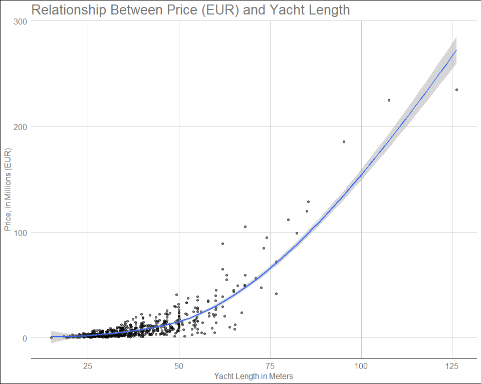

#### How old are the yachts for sale right now?

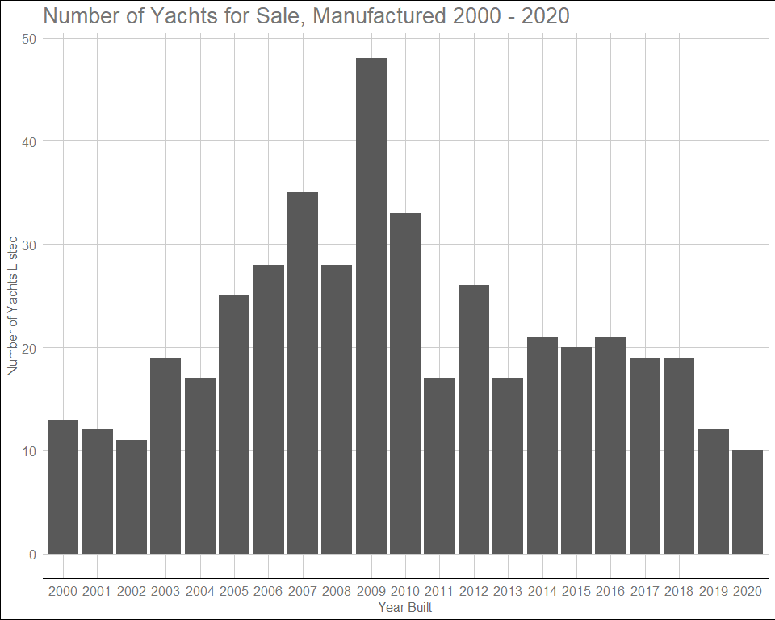

#### Are some engine manufacturers making faster yachts than others?

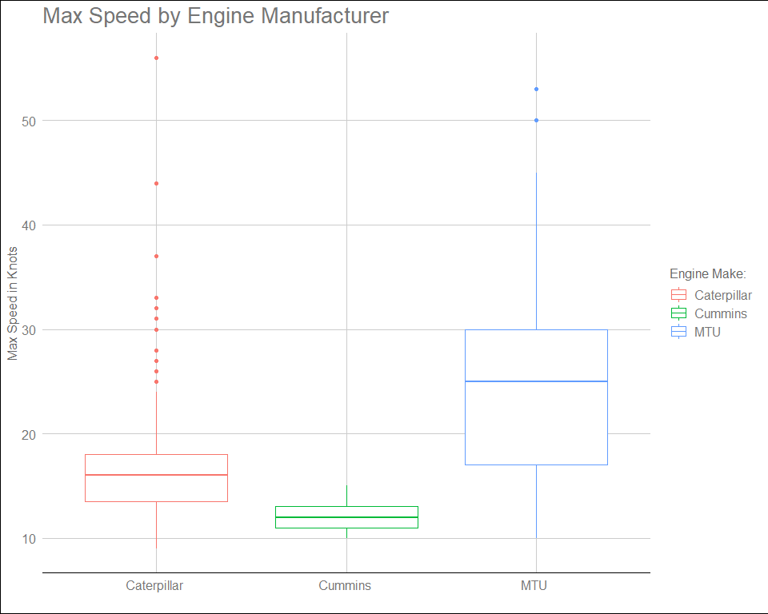

## Summary

It only took a few lines of code to scrape all the yachts for sale on Boat International. With this data, we can easily analyze the current yacht market.

The exploratory data analysis yielded the following insights:

**Longer yachts are more expensive and more rare.**  
There is obviously a positive correlation between yacht length and price. After 50 meters, the price starts increasing fast. Yachts that are 75+ meters are a small fraction of those available for sale.

**The most common yacht vintage is the 2007 - 2010 range.**  
It is more common to find a yacht for sale that was manufactured in 2007 - 2010. This is quite easy to spot on the histogram, but we would need to do more research to find out why.

**Yachts with MTU engines have a higher max speed, on average.**  
Yachts with engines from MTU tend to be faster on average. However, there are some fast Caterpillar yachts for sale, and top speeds from MTU and Caterpillar are in the same ballpark. Yachts with Cummins engines are clearly lagging behind.